# Análisis de Habilidades Blandas en Postgrados (Sección Uruguay)

Juan Esteban Gómez y Juan C. Correa

2024-06-23

# Carga de datos

Primero, se carga el paquete “readtext” y se lee el directorio “Uruguay” para extraer los textos de los documentos PDF. Luego, se elimina la extensión “.pdf” del identificador de cada documento.

```r
library(readtext)
URU <- readtext("Uruguay")
URU$doc_id <- gsub(".pdf", "", URU$doc_id)
```

Luego, pasamos a relacionar cada programa de postgrado con su correspondiente nivel educativo para observar cuántos programas hay de cada nivel:

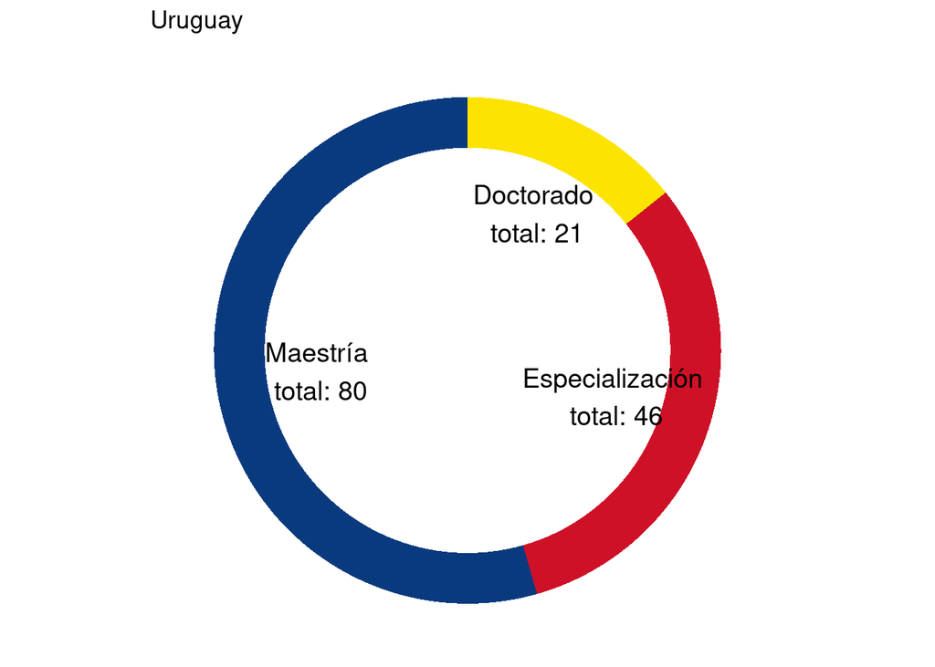

```r
library(dplyr)
URU <- mutate(URU,
              Program = ifelse(
                grepl("Doctorado en", text), "Doctorado",
                ifelse(grepl("Maestría|Magíster en|MAGISTER EN", text), "Maestría",
                       "Especialización")))
Programas <- data.frame(table(URU$Program))
colnames(Programas)[1] <- "Programa"
colnames(Programas)[2] <- "Total"

library(ggplot2)
Programas$fraction = Programas$Total / sum(Programas$Total)
Programas$ymax = cumsum(Programas$fraction)
Programas$ymin = c(0, head(Programas$ymax, n=-1))
Programas$ymax <- cumsum(Programas$fraction)
Programas$ymin <- c(0, head(Programas$ymax, n=-1))
Programas$labelPosition <- (Programas$ymax + Programas$ymin) / 2
Programas$label <- paste0(Programas$Programa, "\n total: ", Programas$Total)
ggplot(Programas, aes(ymax=ymax, ymin=ymin, xmax=4, xmin=3, fill=Programa)) +
  geom_rect() +
  geom_text(x=2, aes(y=labelPosition, label=label, color=Programa), size=5) +
  scale_fill_manual(values=c("Doctorado"="#FCE300", "Maestría"="#0A3A7E", "Especialización"="#CE1127")) +
  scale_color_manual(values=c("Doctorado"="black", "Maestría"="black", "Especialización"="black")) + # Custom text colors
  coord_polar(theta="y") +
  xlim(c(-1, 4)) +
  theme_void() +
  theme(legend.position = "none") +
  ggtitle("Uruguay")
```

Ahora, pasamos a crear el corpus lingüístico. Para ello, cada documento se va a descomponer en número de palabras totales (tokens), número de palabras únicas (types) y número de oraciones (sentences). Esto nos permitirá observar la longitud de cada oferta de postgrado.

```r
library(quanteda)
TextsURU <- corpus(URU$text)
docvars(TextsURU, "Program") <- URU$Program
docvars(TextsURU, "Country") <- "Uruguay"
head(summary(TextsURU), 3)
```

```
##    Text Types Tokens Sentences   Program Country
## 1 text1   371    930        40 Doctorado Uruguay
## 2 text2  1121   4350       131 Doctorado Uruguay
## 3 text3   400    921        24 Doctorado Uruguay
```

```r
ProgramsURU <- tokens(TextsURU,
                      remove_numbers = TRUE,
                      remove_punct = TRUE,
                      remove_url = TRUE,
                      remove_symbols = TRUE) %>%
  tokens_remove(stopwords("spanish"))
```

Ahora, pasamos a hacer a buscar con el filtro contextual así:

```r
s1 <- data.frame(kwic(ProgramsURU, pattern = phrase("pensamiento crítico")))
s2 <- data.frame(kwic(ProgramsURU, pattern = phrase("solucionar problemas")))
s3 <- data.frame(kwic(ProgramsURU, pattern = "comunicar"))
s4 <- data.frame(kwic(ProgramsURU, pattern = "creatividad"))
s5 <- data.frame(kwic(ProgramsURU, pattern = "paciencia"))
s6 <- data.frame(kwic(ProgramsURU, pattern = "crear"))
s7 <- data.frame(kwic(ProgramsURU, pattern = "liderar"))
s8 <- data.frame(kwic(ProgramsURU, pattern = "resolver"))
s9 <- data.frame(kwic(ProgramsURU, pattern = "comprometer"))
s10 <- data.frame(kwic(ProgramsURU, pattern = "comprometerse"))
s11 <- data.frame(kwic(ProgramsURU, pattern = "gestionar"))
s12 <- data.frame(kwic(ProgramsURU, pattern = "reflexionar"))
s13 <- data.frame(kwic(ProgramsURU, pattern = "controlar"))
s14 <- data.frame(kwic(ProgramsURU, pattern = "ético"))
s15 <- data.frame(kwic(ProgramsURU, pattern = "tolerar"))
s16 <- data.frame(kwic(ProgramsURU, pattern = "URUumentar"))
s17 <- data.frame(kwic(ProgramsURU, pattern = "conflictos"))
s18 <- data.frame(kwic(ProgramsURU, pattern = "negociar"))
s19 <- data.frame(kwic(ProgramsURU, pattern = "comprender"))
s20 <- data.frame(kwic(ProgramsURU, pattern = "equipos"))
s21 <- data.frame(kwic(ProgramsURU, pattern = "planificar"))
s22 <- data.frame(kwic(ProgramsURU, pattern = "generar"))
s23 <- data.frame(kwic(ProgramsURU, pattern = "empatía"))
s24 <- data.frame(kwic(ProgramsURU, pattern = "compartir"))
s25 <- data.frame(kwic(ProgramsURU, pattern = "analizar"))
s26 <- data.frame(kwic(ProgramsURU, pattern = "reconocer"))
s27 <- data.frame(kwic(ProgramsURU, pattern = "orientar"))
s28 <- data.frame(kwic(ProgramsURU, pattern = "respetar"))
s29 <- data.frame(kwic(ProgramsURU, pattern = "motivar"))
s30 <- data.frame(kwic(ProgramsURU, pattern = "cooperar"))
s31 <- data.frame(kwic(ProgramsURU, pattern = "fortalecer"))
s32 <- data.frame(kwic(ProgramsURU, pattern = "impulsar"))
s33 <- data.frame(kwic(ProgramsURU, pattern = "acercar"))
s34 <- data.frame(kwic(ProgramsURU, pattern = "ayudar"))
s35 <- data.frame(kwic(ProgramsURU, pattern = "cambiar"))
s36 <- data.frame(kwic(ProgramsURU, pattern = "apreciar"))
s37 <- data.frame(kwic(ProgramsURU, pattern = "dirigir"))
s38 <- data.frame(kwic(ProgramsURU, pattern = "fomentar"))
s39 <- data.frame(kwic(ProgramsURU, pattern = "interactuar"))
s40 <- data.frame(kwic(ProgramsURU, pattern = "identificar"))
s41 <- data.frame(kwic(ProgramsURU, pattern = "competir"))
s42 <- data.frame(kwic(ProgramsURU, pattern = "manifestar"))
s43 <- data.frame(kwic(ProgramsURU, pattern = "responsable"))
s44 <- data.frame(kwic(ProgramsURU, pattern = "evaluar"))
s45 <- data.frame(kwic(ProgramsURU, pattern = "innovar"))
s46 <- data.frame(kwic(ProgramsURU, pattern = "decidir"))
s47 <- data.frame(kwic(ProgramsURU, pattern = phrase("tomar decisiones")))
s48 <- data.frame(kwic(ProgramsURU, pattern = "flexibilidad"))
s49 <- data.frame(kwic(ProgramsURU, pattern = "persua*"))
s50 <- data.frame(kwic(ProgramsURU, pattern = "convencer"))

df_list <- mget(paste0("s", 1:50))
SS <- do.call(rbind, df_list)
SS$Skill <- rownames(SS)
SS$Skill <- gsub("\\..*", "", SS$Skill)

SkillsURU <- data.frame(Country = "Uruguay",
                        SkillCode = c(paste0("s", 1:50)),
                        Skill = c("pensamiento crítico",
                                  "solucionar problemas",
                                  "comunicar",
                                  "creatividad",
                                  "paciencia",
                                  "crear",
                                  "liderar",
                                  "resolver",
                                  "comprometer",
                                  "comprometerse",
                                  "gestionar",
                                  "reflexionar",
                                  "controlar",
                                  "ético",
                                  "tolerar",
                                  "URUumentar",
                                  "conflictos",
                                  "negociar",
                                  "comprender",
                                  "equipos",
                                  "planificar",
                                  "generar",
                                  "empatía",
                                  "compartir",
                                  "analizar",
                                  "reconocer",
                                  "orientar",
                                  "respetar",
                                  "motivar",
                                  "cooperar",
                                  "fortalecer",
                                  "impulsar",
                                  "acercar",
                                  "ayudar",
                                  "cambiar",
                                  "apreciar",
                                  "dirigir",
                                  "fomentar",
                                  "interactuar",
                                  "identificar",
                                  "competir",
                                  "manifestar",
                                  "responsable",
                                  "evaluar",
                                  "innovar",
                                  "decidir",
                                  "tomar decisiones",
                                  "flexibilidad",
                                  "persua*",
                                  "convencer"))
```

# Paso 2: (Modelado de Red de Habilidades)

Ahora, pasamos a modelar las relaciones entre las habilidades y los programas de postgrado. Para ello, vamos a usar los datos de la tabla SS resultante del último código del paso anterior para construir la redd a través de una lista de aristas.

```r
networkURU <- SS[c(1,8)]
head(networkURU, 3)
```

```
##      docname Skill
## s1.1  text10    s1
## s1.2  text77    s1
## s1.3  text77    s1
```

Ahora, pasamos a graficar la red bipartita entre habilidades y programas

```r
library(igraph)
bn7 <- graph.data.frame(networkURU,directed=FALSE)
bipartite_mapping(bn7)
```

```
## $res
## [1] TRUE
##
## $type
##  text10  text77  text87  text17  text60  text15  text21  text37  text38  text53
##   FALSE   FALSE   FALSE   FALSE   FALSE   FALSE   FALSE   FALSE   FALSE   FALSE
##  text69  text72  text86 text103 text106 text114 text116  text14  text51 text105
##   FALSE   FALSE   FALSE   FALSE   FALSE   FALSE   FALSE   FALSE   FALSE   FALSE
## text112 text113 text117 text132 text137   text7  text11  text23  text32  text39
##   FALSE   FALSE   FALSE   FALSE   FALSE   FALSE   FALSE   FALSE   FALSE   FALSE
##  text47  text73  text80  text89  text91  text95  text97 text107 text147  text24
##   FALSE   FALSE   FALSE   FALSE   FALSE   FALSE   FALSE   FALSE   FALSE   FALSE
##  text28  text30  text42  text52  text56  text62  text66  text74  text76 text119
##   FALSE   FALSE   FALSE   FALSE   FALSE   FALSE   FALSE   FALSE   FALSE   FALSE
##  text43  text44  text45 text141 text133  text79  text90  text31 text102 text121
##   FALSE   FALSE   FALSE   FALSE   FALSE   FALSE   FALSE   FALSE   FALSE   FALSE
##  text25  text33  text34  text65  text67  text94  text96  text59  text99 text111
##   FALSE   FALSE   FALSE   FALSE   FALSE   FALSE   FALSE   FALSE   FALSE   FALSE
## text118 text123 text124 text130 text131 text135 text136 text127   text4   text8
##   FALSE   FALSE   FALSE   FALSE   FALSE   FALSE   FALSE   FALSE   FALSE   FALSE
##  text16  text40 text101 text109 text134 text138 text146 text122   text1  text35
##   FALSE   FALSE   FALSE   FALSE   FALSE   FALSE   FALSE   FALSE   FALSE   FALSE
##  text36  text41  text81 text100 text115  text78  text93 text125  text22  text26
##   FALSE   FALSE   FALSE   FALSE   FALSE   FALSE   FALSE   FALSE   FALSE   FALSE
##  text50  text57  text82   text2 text104  text88  text84  text49  text85  text98
##   FALSE   FALSE   FALSE   FALSE   FALSE   FALSE   FALSE   FALSE   FALSE   FALSE
##  text54 text140 text145  text75      s1      s3      s4      s6      s7      s8
##   FALSE   FALSE   FALSE   FALSE    TRUE    TRUE    TRUE    TRUE    TRUE    TRUE
##     s11     s12     s13     s14     s17     s18     s19     s20     s21     s22
##    TRUE    TRUE    TRUE    TRUE    TRUE    TRUE    TRUE    TRUE    TRUE    TRUE
##     s23     s24     s25     s26     s27     s29     s31     s32     s33     s34
##    TRUE    TRUE    TRUE    TRUE    TRUE    TRUE    TRUE    TRUE    TRUE    TRUE
##     s35     s36     s37     s38     s39     s40     s42     s43     s44     s45
##    TRUE    TRUE    TRUE    TRUE    TRUE    TRUE    TRUE    TRUE    TRUE    TRUE
##     s46     s47     s48     s49
##    TRUE    TRUE    TRUE    TRUE
```

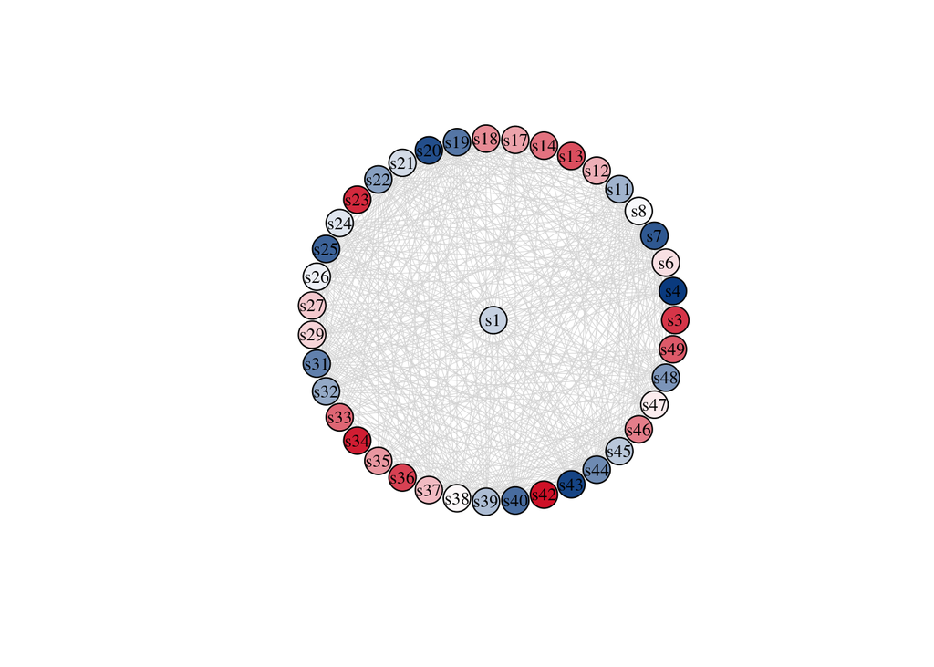

```r
V(bn7)$type <- bipartite_mapping(bn7)$type
V(bn7)$shape <- ifelse(V(bn7)$type, "circle", "square")
V(bn7)$label.cex <- ifelse(V(bn7)$type, 0.5, 1)
V(bn7)$size <- sqrt(igraph::degree(bn7))
E(bn7)$color <- "lightgrey"

bn7.pr <- bipartite_projection(bn7)
Terms <- bn7.pr$proj2

pave <- data.frame(igraph::betweenness(Terms))

centrality_scores <- igraph::eigen_centrality(Terms)
centrality_scores <- centrality_scores$vector

color_palette <- colorRampPalette(c("#CE1127", "white", "#0A3A7E"))(length(unique(centrality_scores)))

# Assign URUors to nodes based on their normalized centrality scores
node_colors <- color_palette[rank(centrality_scores)]

# Plot the network with node URUors based on centrality
set.seed(915)


plot(Terms, vertex.label.color = "black", vertex.label.cex = 0.8, vertex.color = node_colors, vertex.size = 15, edge.width = 0.5, edge.color = "lightgray", layout = layout_as_star, main = "")
```

Seguimos con el cálculo de la importancia de cada habilidad y analicemos la correlación entre los cuatro indicadores de centralidad para ver si se comportan de una manera semejante a lo esperado por la evidencia empírica sobre indicadores de centralidad.

```r
BNURU <- graph.data.frame(networkURU, directed = FALSE)
ProgramsURU <- data.frame(Degree = igraph::degree(BNURU),
                          Closeness = igraph::closeness(BNURU),
                          Betweennes = igraph::betweenness(BNURU),
                          Eigen = igraph::eigen_centrality(BNURU))
ProgramsURU <- ProgramsURU[ -c(5:25) ]
rownames(ProgramsURU)
```

```
##   [1] "text10"  "text77"  "text87"  "text17"  "text60"  "text15"  "text21"
##   [8] "text37"  "text38"  "text53"  "text69"  "text72"  "text86"  "text103"
##  [15] "text106" "text114" "text116" "text14"  "text51"  "text105" "text112"
##  [22] "text113" "text117" "text132" "text137" "text7"   "text11"  "text23"
##  [29] "text32"  "text39"  "text47"  "text73"  "text80"  "text89"  "text91"
##  [36] "text95"  "text97"  "text107" "text147" "text24"  "text28"  "text30"
##  [43] "text42"  "text52"  "text56"  "text62"  "text66"  "text74"  "text76"
##  [50] "text119" "text43"  "text44"  "text45"  "text141" "text133" "text79"
##  [57] "text90"  "text31"  "text102" "text121" "text25"  "text33"  "text34"
##  [64] "text65"  "text67"  "text94"  "text96"  "text59"  "text99"  "text111"
##  [71] "text118" "text123" "text124" "text130" "text131" "text135" "text136"
##  [78] "text127" "text4"   "text8"   "text16"  "text40"  "text101" "text109"
##  [85] "text134" "text138" "text146" "text122" "text1"   "text35"  "text36"
##  [92] "text41"  "text81"  "text100" "text115" "text78"  "text93"  "text125"
##  [99] "text22"  "text26"  "text50"  "text57"  "text82"  "text2"   "text104"
## [106] "text88"  "text84"  "text49"  "text85"  "text98"  "text54"  "text140"
## [113] "text145" "text75"  "s1"      "s3"      "s4"      "s6"      "s7"
## [120] "s8"      "s11"     "s12"     "s13"     "s14"     "s17"     "s18"
## [127] "s19"     "s20"     "s21"     "s22"     "s23"     "s24"     "s25"
## [134] "s26"     "s27"     "s29"     "s31"     "s32"     "s33"     "s34"
## [141] "s35"     "s36"     "s37"     "s38"     "s39"     "s40"     "s42"
## [148] "s43"     "s44"     "s45"     "s46"     "s47"     "s48"     "s49"
```

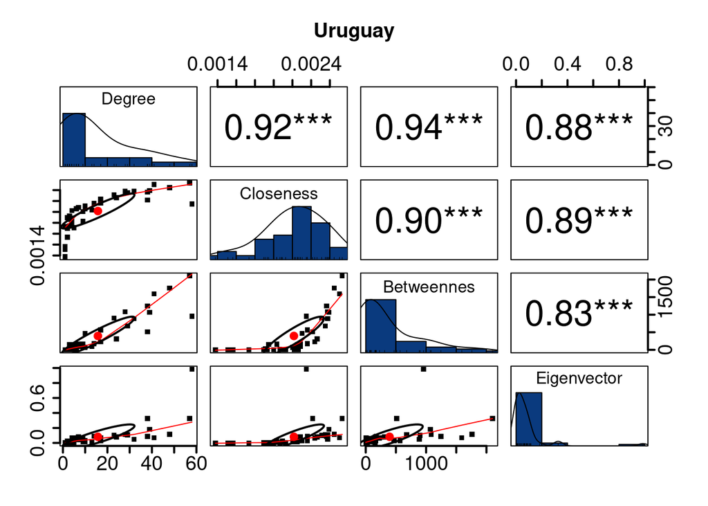

```r
ProgramsURU$SS <- rownames(ProgramsURU)
ProgramsURU <- ProgramsURU[order(ProgramsURU$SS), ]
ProgramsURU <- ProgramsURU[grepl("s", ProgramsURU$SS), ]
ProgramsURU <- ProgramsURU[1:4]
colnames(ProgramsURU)[4] <- "Eigenvector"



library(psych)

pairs.panels(ProgramsURU,
             method = "spearman",
             hist.col = "#0A3A7E",
             density = TRUE,
             ellipses = TRUE,
             pch = 15,
             cex = 1,
             cex.axis = 1.8,
             cex.labels = 1.5,
             lwd = 2,
             rug = TRUE,
             stars = TRUE,
             main = "Uruguay")
```

Ahora, veamos el ranking de las diez habilidades más importantes

```r
IURU <- as_biadjacency_matrix(BNURU, names = TRUE, sparse = TRUE, types = bipartite_mapping(BNURU)$type)
IURU2 <- as.matrix(IURU)

rownames(ProgramsURU)[order(ProgramsURU$Eigenvector, decreasing = TRUE)]
```

```
##  [1] "s4"  "s43" "s20" "s7"  "s25" "s19" "s40" "s31" "s48" "s44" "s11" "s39"
## [13] "s45" "s22" "s32" "s1"  "s26" "s24" "s8"  "s38" "s21" "s6"  "s47" "s29"
## [25] "s27" "s17" "s37" "s12" "s35" "s18" "s46" "s14" "s33" "s49" "s13" "s36"
## [37] "s3"  "s23" "s34" "s42"
```

```r
selected_columns <- head(rownames(ProgramsURU)[order(ProgramsURU$Eigenvector, decreasing = TRUE)], 10)
# Let's pick the most important soft skills
# as per their eigenvector centrality

current_column_names <- colnames(IURU2)

# Subset the matrix by column names
IURU3 <- IURU2[, selected_columns, drop = FALSE]

current_column_names <- colnames(IURU3)


# Create a vector to hold the mapped skill names
mapped_skill_names <- character(length(current_column_names))


for (i in seq_along(current_column_names)) {

  skill_index <- match(current_column_names[i], SkillsURU$SkillCode)

  # If a match is found, map the skill code to its name
  if (!is.na(skill_index)) {
    mapped_skill_names[i] <- SkillsURU$Skill[skill_index]
  } else {
    # Handle unmatched column names as needed
    # For example, assign a default value or leave blank
    mapped_skill_names[i] <- "Unmatched"
  }
}

# Replace the column names of IM3 with the mapped skill names
colnames(IURU3) <- mapped_skill_names
colnames(IURU3)
```

```
##  [1] "creatividad"  "responsable"  "equipos"      "liderar"      "analizar"
##  [6] "comprender"   "identificar"  "fortalecer"   "flexibilidad" "evaluar"
```

# Paso 3 (Visualización de Red Bipartita)

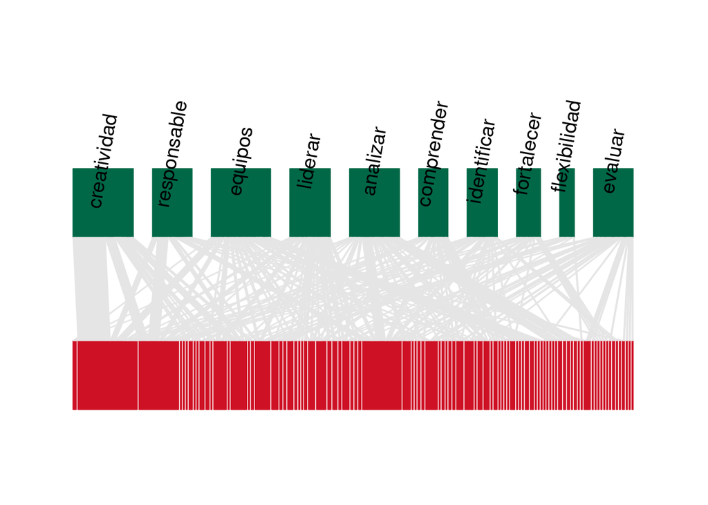

```r
library(bipartite)
plotweb(IURU3, method = "normal",
        col.high = "#006847",
        bor.col.high = "#006847",
        col.low = "#CE1125",
        bor.col.low = "#CE1125",
        col.interaction = "grey90",
        bor.col.interaction = "grey90",
        low.lablength = 0,
        text.rot = 80,
        high.y = 1,
        ybig = 0.8,
        labsize = 2)
```